# Jonathan Diener: Aliza

Author

Reinhold Kliegl

Published

September 17, 2022

# 1 Background

The aim of this study was to evaluate the acceptability and effectiveness of a chatbot in reducing sedentary behavior among university students.

## 1.1 Methods

The chatbot “Aliza” was developed in a human-centered design process. Subsequently, Aliza was evaluated in a pretest-posttest quasi-experimental pilot study involving German university students. Subjects interacted with Aliza, deployed on Slack Messenger, for two weeks. Each day, they were offered to schedule activity breaks. Aliza then reminded subjects of the breaks and sent them exercise challenges or videos. Acceptability was measured including usability, perceived enjoyment, and attitude toward using a chatbot to promote activity breaks. To evaluate effectiveness in terms of behavior change, daily activity breaks were assessed at baseline and during the first and second week of intervention.

## 1.2 Main research questions

- Will the developed chatbot demonstrate high acceptability among university students?
- Will the usage of the chatbot lead to a significant increase in activity breaks compared to pre-intervention?

## 1.3 Variables

- Sozioökonomische Daten (Geschlecht, angestrebter Abschluss etc.)
- Studiumsbezogene Daten (Lernort: Ort, an dem primär gelernt wird; Art der Lehre: Präsenz vs. Online, etc.)
- Daten, die sich auf das Sitzverhalten und dessen Auswirkungen beziehen (Durchschnittliche Sitzzeit pro Tag, Gesundheitliche Auswirkungen durch das Sitzen, Anzahl Bewegungspausen vor der Intervention)
- Akzeptanz des Chatbots (Usability: Chatbot Usability Score; perceived enjoyment, attitude toward using a chatbot, future usage intention)
- Während der Intervention erhobene Daten: Jeweils von Montag bis Freitag wurde die Anzahl an durchgeführten Bewegungspausen des Vortages abgefragt, montags für das vergangene Wochenende. Dabei wurden jeweils die nach Aufforderung von Aliza durchgeführten Bewegungspausen sowie die in Eigeninitiative ausgeführten Bewegungspausen abgefragt. Für jeden Tag gibt es somit zwei Variablen zu den Bewegungspausen.
- Daten zu den subjektiven Effekten der Bewegungspausen auf das physische und mentale Wohlbefinden sowie auf kognitive Aspekte (z.B. Konzentrationsfähigkeit)
- Daten zu technischen Rahmenbedingungen (Endgerät, über das mit dem Chatbot kommuniziert wurde; Sind Push-Benachrichtigungen durchgekommen, etc.)

# 2 Preprocessing

## 2.1 RK style guide

- Random factors should be factors, not integers!
- Factors capitalized, continuous variables in lower case
- `Subj` instead of `ID`; prefix subject and item numbers with `S` and `I`
- Short variable names and factor levels, but respect tradeoff with mmemonic value
- Labels should be of equal length
- Hint: Leave out vowels in names and labels
- See Jenny Bryan’s [Naming Things](https://docplayer.net/55248970-Naming-things-prepared-by-jenny-bryan-for-reproducible-science-workshop.html)

## 2.2 Packages

```r
library(easystats)
library(tidyverse)
library(haven)
library(labelled)
library(lme4)
library(summarytools)
# respecting color vision deficiency
cbPalette <- c( "#0072B2", "#D55E00", "#009E73", "#CC79A7",
                "#F0E442", "#56B4E9", "#999999", "#E69F00")
```

## 2.3 Read and transform data

```r
dat_w <-
   read_sav("DIENER.sav") |>
   remove_labels() |>
   select(Subj=1, Sex=2, 20, 31, 32, 33, 53, 47, 48, 49,
          w11= 8, w12= 9, w13=10, w14=11, w15=12, w16=13,
          w21=56, w22=57, w23=58, w24=59, w25=60, w26=61) |>
   mutate( Sex = factor(Sex, levels=1:2, labels=c("female", "male")))

stview(dfSummary(dat_w))

table(dat_w$Subj, dat_w$W1_Aliza_ingesamt)
```

A bit too complex for me…

- Replacing one missing value in `preAtt` and two in `postAtt`

```r
dat_w <-
   read_sav("DIENER.sav") |>
   remove_labels() |>
   select(Subj=1, Sex=2, Aliza1=31, preAtt=20, postAtt=53) |>
   mutate( Subj = factor(Subj),
           Sex = factor(Sex, levels=1:2, labels=c("female", "male")),
           Group = factor(ifelse(is.na(Aliza1), "control", "treatment")),
           preAtt = ifelse(is.na(preAtt), 24, preAtt),
           postAtt = ifelse(is.na(postAtt), 25, postAtt)
   )

stview(dfSummary(dat_w))
```

```
Switching method to 'browser'
```

```
Output file written: /var/folders/nd/l59kkqd951xdb29k4rt4yzj80000gn/T//RtmpSwws63/fileb676427dd02c.html
```

From wide to long format

```r
dat <-
  dat_w |>
  pivot_longer(4:5, names_to = "PrePost",  names_transform = "as.factor",
               values_to = "attitude") |>
  mutate(PrePost=fct_rev(PrePost))
```

Check need for transformation

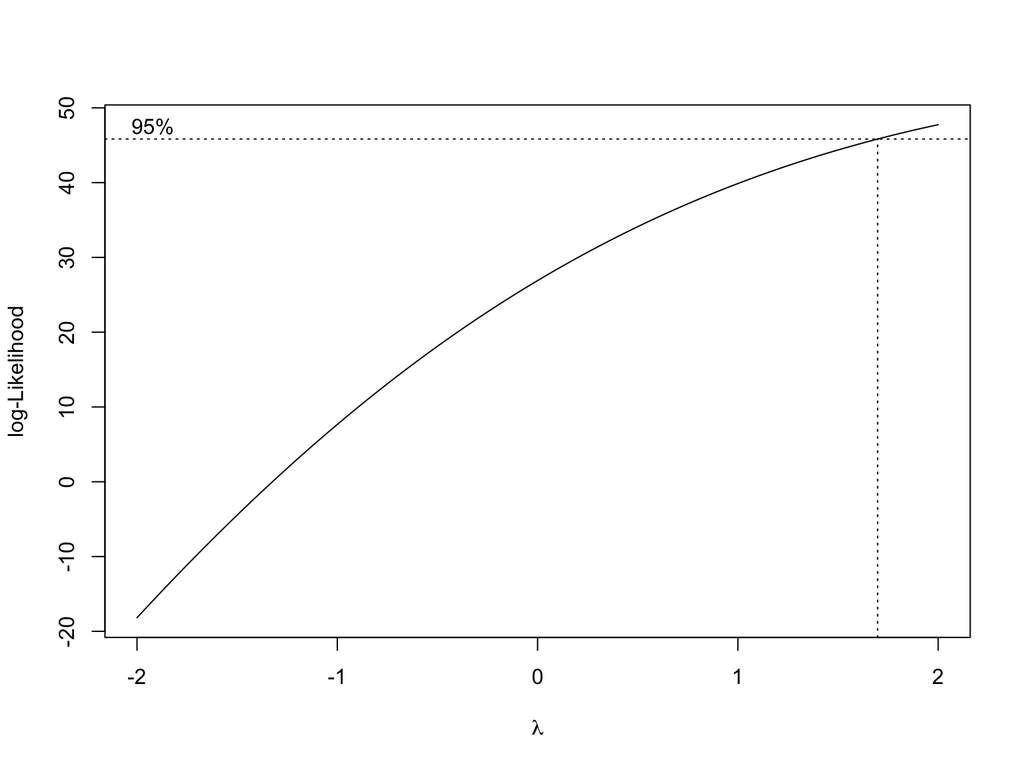

```r
MASS::boxcox(attitude ~ 1 + Subj, data=dat)
```

Condition means

```r
dat |>
  group_by(Group, PrePost) |>
  summarise(N=n(), M=mean(attitude), SE=sd(attitude)/sqrt(N))
```

```
# A tibble: 4 × 5
# Groups:   Group [2]
  Group     PrePost     N     M    SE
  <fct>     <fct>   <int> <dbl> <dbl>
1 control   preAtt     20  23.8 0.674
2 control   postAtt    20  23.6 0.881
3 treatment preAtt     14  24.2 1.14
4 treatment postAtt    14  25   0.920
```

LMM

```r
contrasts(dat$Group) <- contr.sum(2)
contrasts(dat$PrePost) <- contr.sum(2)

m1 <-  lmer(attitude ~ 1  + Group*PrePost + (1 | Subj), data=dat, REML=FALSE,
            control=lmerControl(calc.derivs=FALSE))
print(summary(m1), corr=FALSE)
```

```
Linear mixed model fit by maximum likelihood  ['lmerMod']
Formula: attitude ~ 1 + Group * PrePost + (1 | Subj)
   Data: dat
Control: lmerControl(calc.derivs = FALSE)

     AIC      BIC   logLik deviance df.resid
   361.9    375.2   -175.0    349.9       62

Scaled residuals:
    Min      1Q  Median      3Q     Max
-2.6306 -0.2824  0.1428  0.4645  1.3941

Random effects:
 Groups   Name        Variance Std.Dev.
 Subj     (Intercept) 7.666    2.769
 Residual             4.979    2.231
Number of obs: 68, groups:  Subj, 34

Fixed effects:
                Estimate Std. Error t value
(Intercept)      24.1536     0.5552  43.501
Group1           -0.4536     0.5552  -0.817
PrePost1         -0.1214     0.2749  -0.442
Group1:PrePost1   0.2714     0.2749   0.987
```

```r
contrasts(dat$Sex) <- contr.sum(2)

m2 <-  lmer(attitude ~ 1  + Group*PrePost*Sex + (1 | Subj), data=dat, REML=FALSE,
            control=lmerControl(calc.derivs=FALSE))
print(summary(m2), corr=FALSE)
```

```
Linear mixed model fit by maximum likelihood  ['lmerMod']
Formula: attitude ~ 1 + Group * PrePost * Sex + (1 | Subj)
   Data: dat
Control: lmerControl(calc.derivs = FALSE)

     AIC      BIC   logLik deviance df.resid
   365.4    387.6   -172.7    345.4       58

Scaled residuals:
    Min      1Q  Median      3Q     Max
-2.5572 -0.3029  0.1667  0.4965  1.5376

Random effects:
 Groups   Name        Variance Std.Dev.
 Subj     (Intercept) 6.476    2.545
 Residual             4.944    2.224
Number of obs: 68, groups:  Subj, 34

Fixed effects:
                     Estimate Std. Error t value
(Intercept)          24.01089    0.52545  45.696
Group1               -0.37453    0.52545  -0.713
PrePost1             -0.10938    0.27619  -0.396
Sex1                  1.09422    0.52545   2.082
Group1:PrePost1       0.27604    0.27619   0.999
Group1:Sex1          -0.45786    0.52545  -0.871
PrePost1:Sex1        -0.10938    0.27619  -0.396
Group1:PrePost1:Sex1 -0.05729    0.27619  -0.207
```

# 3 Appendix